# Project: Investigating Gun Data

- Introduction
- Data Wrangling
- Exploratory Data Analysis
- Conclusions

## Introduction

21st Century Americans are facing an increasingly politicized landscape, with norms and conventions being challenged at every turn. One of the most resoundingly partisan issues is the subject of gun ownership. American gun ownership is protected under the 2nd Amendment of the Constitution, but is with greater frequency being questioned in light of seemingly increasing violence. This is a contentious political issue, often with impassioned arguments on either side of the aisle. This report attempts to set aside partisan notions to as objectively as possible address trends based on accessible data.

One source of gun data is the Federal Bureau of Investigation's National Instant Criminal Background Check System. In their own words:

> The National Instant Criminal Background Check System, or NICS, is all about saving lives and protecting people from harm—by not letting guns fall into the wrong hands. It also ensures the timely transfer of firearms to eligible gun buyers.

> Mandated by the Brady Handgun Violence Prevention Act of 1993 and launched by the FBI on November 30, 1998, NICS is used by Federal Firearms Licensees (FFLs) to instantly determine whether a prospective buyer is eligible to buy firearms. Before ringing up the sale, cashiers call in a check to the FBI or to other designated agencies to ensure that each customer does not have a criminal record or isn’t otherwise ineligible to make a purchase. More than 230 million such checks have been made, leading to more than 1.3 million denials. [1]

Pairing this dataset with a dataset of census data will allow us to begin to formulate hypotheses about how a proxy for gun sales and demographics interact. This data can be useful to determine a baseline set of statistics about the basics of guns in America, such as whether gun registration is rising or declining, which states have the highest rate of gun registration, and, how gun registration is affected by levels of income/poverty.

It should be stressed that none of these claims can be made with any amount of certainty and may only provide correlational and not causational trends. In order to make claims with a high degree of fidelity and vigor, hypothesis testing or regression analysis would have to be used.

```python
# Use this cell to set up import statements for all of the packages that you
#   plan to use.
import pandas as pd
import numpy as np
import matplotlib.pyplot as plt
% matplotlib inline
import seaborn as sns
sns.set_style('darkgrid')
```

## Data Wrangling

### General Properties

We begin by loading the data and determining basic properties, such as the shape of the data, number of unique values, etc.

```python
# Load your data and print out a few lines.
gun_data = pd.read_csv('gun_data.csv')
censdata = pd.read_csv('U.S. Census Data.csv')
```

#### The NICS data set

We will start with the NICS data set and provide commentary as to initial thoughts of what th data contains and how it may need to be cleaned. A typical .head() command showed that the NICS gun data shows for what purpose the background check was being conducted and for what type of gun.

```python
#Inspect gun_data
gun_data.head()
```

|  | month | state | permit | permit_recheck | handgun | long_gun | other | multiple | admin | prepawn_handgun | ... | returned_other | rentals_handgun | rentals_long_gun | private_sale_handgun | private_sale_long_gun | private_sale_other | return_to_seller_handgun | return_to_seller_long_gun | return_to_seller_other | totals |
| --- | --- | --- | --- | --- | --- | --- | --- | --- | --- | --- | --- | --- | --- | --- | --- | --- | --- | --- | --- | --- | --- |
| 0 | 2017-09 | Alabama | 16717.0 | 0.0 | 5734.0 | 6320.0 | 221.0 | 317 | 0.0 | 15.0 | ... | 0.0 | 0.0 | 0.0 | 9.0 | 16.0 | 3.0 | 0.0 | 0.0 | 3.0 | 32019 |
| 1 | 2017-09 | Alaska | 209.0 | 2.0 | 2320.0 | 2930.0 | 219.0 | 160 | 0.0 | 5.0 | ... | 0.0 | 0.0 | 0.0 | 17.0 | 24.0 | 1.0 | 0.0 | 0.0 | 0.0 | 6303 |
| 2 | 2017-09 | Arizona | 5069.0 | 382.0 | 11063.0 | 7946.0 | 920.0 | 631 | 0.0 | 13.0 | ... | 0.0 | 0.0 | 0.0 | 38.0 | 12.0 | 2.0 | 0.0 | 0.0 | 0.0 | 28394 |
| 3 | 2017-09 | Arkansas | 2935.0 | 632.0 | 4347.0 | 6063.0 | 165.0 | 366 | 51.0 | 12.0 | ... | 0.0 | 0.0 | 0.0 | 13.0 | 23.0 | 0.0 | 0.0 | 2.0 | 1.0 | 17747 |
| 4 | 2017-09 | California | 57839.0 | 0.0 | 37165.0 | 24581.0 | 2984.0 | 0 | 0.0 | 0.0 | ... | 0.0 | 0.0 | 0.0 | 0.0 | 0.0 | 0.0 | 0.0 | 0.0 | 0.0 | 123506 |

5 rows × 27 columns

Noticing that there are several columns that have zeroes straight down, it seems prudent to check the tail end of the dataset. This has shown that there are several missing values and the data clean portion will have to be extensive to account for the high number of zeros and high number of missing data values.

```python
#Inspect tail end of gun_data
gun_data.tail()
```

|  | month | state | permit | permit_recheck | handgun | long_gun | other | multiple | admin | prepawn_handgun | ... | returned_other | rentals_handgun | rentals_long_gun | private_sale_handgun | private_sale_long_gun | private_sale_other | return_to_seller_handgun | return_to_seller_long_gun | return_to_seller_other | totals |
| --- | --- | --- | --- | --- | --- | --- | --- | --- | --- | --- | --- | --- | --- | --- | --- | --- | --- | --- | --- | --- | --- |
| 12480 | 1998-11 | Virginia | 0.0 | NaN | 14.0 | 2.0 | NaN | 8 | 0.0 | NaN | ... | NaN | NaN | NaN | NaN | NaN | NaN | NaN | NaN | NaN | 24 |
| 12481 | 1998-11 | Washington | 1.0 | NaN | 65.0 | 286.0 | NaN | 8 | 1.0 | NaN | ... | NaN | NaN | NaN | NaN | NaN | NaN | NaN | NaN | NaN | 361 |
| 12482 | 1998-11 | West Virginia | 3.0 | NaN | 149.0 | 251.0 | NaN | 5 | 0.0 | NaN | ... | NaN | NaN | NaN | NaN | NaN | NaN | NaN | NaN | NaN | 408 |
| 12483 | 1998-11 | Wisconsin | 0.0 | NaN | 25.0 | 214.0 | NaN | 2 | 0.0 | NaN | ... | NaN | NaN | NaN | NaN | NaN | NaN | NaN | NaN | NaN | 241 |
| 12484 | 1998-11 | Wyoming | 8.0 | NaN | 45.0 | 49.0 | NaN | 5 | 0.0 | NaN | ... | NaN | NaN | NaN | NaN | NaN | NaN | NaN | NaN | NaN | 107 |

5 rows × 27 columns

At this point, it becomes useful to take a look at the structure of the data itself, which is done by looking at the number of unique values, the shape of the data, and other info about the gun data set.

```python
#Get typical metrics about gun_data
print(gun_data.nunique())
print("\n")
gun_data.info()
print("\n")
print(gun_data.shape)
sum(gun_data.duplicated())
```

```
month                          227
state                           55
permit                        5390
permit_recheck                 168
handgun                       7381
long_gun                      8350
other                         1226
multiple                      1387
admin                          499
prepawn_handgun                 90
prepawn_long_gun               133
prepawn_other                   16
redemption_handgun            1893
redemption_long_gun           2370
redemption_other                47
returned_handgun               237
returned_long_gun              113
returned_other                  34
rentals_handgun                  9
rentals_long_gun                 8
private_sale_handgun           152
private_sale_long_gun          136
private_sale_other              43
return_to_seller_handgun        17
return_to_seller_long_gun       17
return_to_seller_other           5
totals                       10218
dtype: int64


<class 'pandas.core.frame.DataFrame'>
RangeIndex: 12485 entries, 0 to 12484
Data columns (total 27 columns):
month                        12485 non-null object
state                        12485 non-null object
permit                       12461 non-null float64
permit_recheck               1100 non-null float64
handgun                      12465 non-null float64
long_gun                     12466 non-null float64
other                        5500 non-null float64
```

[output cut: 10 more lines]

```
returned_other               1815 non-null float64
rentals_handgun              990 non-null float64
rentals_long_gun             825 non-null float64
private_sale_handgun         2750 non-null float64
private_sale_long_gun        2750 non-null float64
private_sale_other           2750 non-null float64
return_to_seller_handgun     2475 non-null float64
return_to_seller_long_gun    2750 non-null float64
return_to_seller_other       2255 non-null float64
totals                       12485 non-null int64
dtypes: float64(23), int64(2), object(2)
memory usage: 2.6+ MB


(12485, 27)
```

```
0
```

```python
print(gun_data['state'].unique())
```

```
['Alabama' 'Alaska' 'Arizona' 'Arkansas' 'California' 'Colorado'
 'Connecticut' 'Delaware' 'District of Columbia' 'Florida' 'Georgia' 'Guam'
 'Hawaii' 'Idaho' 'Illinois' 'Indiana' 'Iowa' 'Kansas' 'Kentucky'
 'Louisiana' 'Maine' 'Mariana Islands' 'Maryland' 'Massachusetts'
 'Michigan' 'Minnesota' 'Mississippi' 'Missouri' 'Montana' 'Nebraska'
 'Nevada' 'New Hampshire' 'New Jersey' 'New Mexico' 'New York'
 'North Carolina' 'North Dakota' 'Ohio' 'Oklahoma' 'Oregon' 'Pennsylvania'
 'Puerto Rico' 'Rhode Island' 'South Carolina' 'South Dakota' 'Tennessee'
 'Texas' 'Utah' 'Vermont' 'Virgin Islands' 'Virginia' 'Washington'
 'West Virginia' 'Wisconsin' 'Wyoming']
```

It has become clear that data cleaning will require deliberation. There are 12,485 rows but in some cases only a few hundred actual data entries. Many of those entries, presumably, are zeros. There are also 55 unique values for states when there are only 50 states in the US (the other five values are the Mariana Islands, Guam, Virgin Islands, Puerto Rico, and District of Columbia) so the extra 5 values will most likely be dropped. The data also appears to be organized by prepawn, redemptions, returns,rentals, etc. One way to to parse the data may be to collate the data by these macro categories. It might also be worthwhile to not consider categories that most likely aren't sales related, like returns or rentals.

#### The Census data set

The census data must also be looked at, with the usual start at an overview of the data.

```python
#Inspect US Census data
censdata.head()
```

|  | Fact | Fact Note | Alabama | Alaska | Arizona | Arkansas | California | Colorado | Connecticut | Delaware | ... | South Dakota | Tennessee | Texas | Utah | Vermont | Virginia | Washington | West Virginia | Wisconsin | Wyoming |
| --- | --- | --- | --- | --- | --- | --- | --- | --- | --- | --- | --- | --- | --- | --- | --- | --- | --- | --- | --- | --- | --- |
| 0 | Population estimates, July 1, 2016, (V2016) | NaN | 4,863,300 | 741,894 | 6,931,071 | 2,988,248 | 39,250,017 | 5,540,545 | 3,576,452 | 952,065 | ... | 865454 | 6651194 | 27,862,596 | 3,051,217 | 624,594 | 8,411,808 | 7,288,000 | 1,831,102 | 5,778,708 | 585,501 |
| 1 | Population estimates base, April 1, 2010, (V2... | NaN | 4,780,131 | 710,249 | 6,392,301 | 2,916,025 | 37,254,522 | 5,029,324 | 3,574,114 | 897,936 | ... | 814195 | 6346298 | 25,146,100 | 2,763,888 | 625,741 | 8,001,041 | 6,724,545 | 1,853,011 | 5,687,289 | 563,767 |
| 2 | Population, percent change - April 1, 2010 (es... | NaN | 1.70% | 4.50% | 8.40% | 2.50% | 5.40% | 10.20% | 0.10% | 6.00% | ... | 0.063 | 0.048 | 10.80% | 10.40% | -0.20% | 5.10% | 8.40% | -1.20% | 1.60% | 3.90% |
| 3 | Population, Census, April 1, 2010 | NaN | 4,779,736 | 710,231 | 6,392,017 | 2,915,918 | 37,253,956 | 5,029,196 | 3,574,097 | 897,934 | ... | 814180 | 6346105 | 25,145,561 | 2,763,885 | 625,741 | 8,001,024 | 6,724,540 | 1,852,994 | 5,686,986 | 563,626 |
| 4 | Persons under 5 years, percent, July 1, 2016, ... | NaN | 6.00% | 7.30% | 6.30% | 6.40% | 6.30% | 6.10% | 5.20% | 5.80% | ... | 0.071 | 0.061 | 7.20% | 8.30% | 4.90% | 6.10% | 6.20% | 5.50% | 5.80% | 6.50% |

5 rows × 52 columns

One possible data cleaning step might be to do something akin to a matrix transpose to the dataset, because at the moment the column headings are by state and the gun data had a state per data row. This may not prove to be necessary, but it may facilitate a data set join.

```python
#Get typical metrics about censdata
print(censdata.nunique())
print(censdata.shape)
print("\n")
censdata.info()
sum(censdata.duplicated())
```

```
Fact              80
Fact Note         15
Alabama           65
Alaska            64
Arizona           64
Arkansas          64
California        63
Colorado          64
Connecticut       63
Delaware          64
Florida           64
Georgia           64
Hawaii            63
Idaho             63
Illinois          65
Indiana           63
Iowa              65
Kansas            65
Kentucky          65
Louisiana         65
Maine             64
Maryland          64
Massachusetts     65
Michigan          64
Minnesota         65
Mississippi       65
Missouri          64
Montana           65
Nebraska          65
Nevada            63
New Hampshire     65
New Jersey        65
New Mexico        64
New York          65
North Carolina    65
North Dakota      63
Ohio              64
Oklahoma          64
Oregon            63
Pennsylvania      65
```

[output cut: 58 more lines]

```
Pennsylvania      65 non-null object
Rhode Island      65 non-null object
South Carolina    65 non-null object
South Dakota      65 non-null object
Tennessee         65 non-null object
Texas             65 non-null object
Utah              65 non-null object
Vermont           65 non-null object
Virginia          65 non-null object
Washington        65 non-null object
West Virginia     65 non-null object
Wisconsin         65 non-null object
Wyoming           65 non-null object
dtypes: object(52)
memory usage: 34.6+ KB
```

```
3
```

```python
print(censdata['Fact Note'].unique())
```

```
[nan '(a)' '(b)' '(c)' 'Includes data not distributed by county.'
 'Includes persons reporting only one race'
 'Hispanics may be of any race, so also are included in applicable race categories'
 'Economic Census - Puerto Rico data are not comparable to U.S. Economic Census data'
 'Either no or too few sample observations were available to compute an estimate, or a ratio of medians cannot be calculated because one or both of the median estimates falls in the lowest or upper interval of an open ended distribution.'
 'Suppressed to avoid disclosure of confidential information'
 'Fewer than 25 firms' 'Footnote on this item in place of data'
 'Not available' 'Suppressed; does not meet publication standards'
 'Not applicable'
 'Value greater than zero but less than half unit of measure shown']
```

Immediately, the "Fact" column jumps out as one that will need to be cleaned. The "Fact" column contains the category the census is attempting to measure (population size, population percent change, etc.) and also contains the data range. These will need to be seperated in order to match appropriate statistics from the census data to the gun data by date or month. These Fact Note data seem specific only to a few rows or potentially footnotes at the end of the dataset. It might be best to either remove these or note these values in other places in the dataset. Unlike the gundata set, there are duplicates we will need to address.

Of course, we also want to see how the 'Facts' are arranged and what we can study the data with.

```python
print(censdata['Fact'].unique())
```

```
['Population estimates, July 1, 2016,  (V2016)'
 'Population estimates base, April 1, 2010,  (V2016)'
 'Population, percent change - April 1, 2010 (estimates base) to July 1, 2016,  (V2016)'
 'Population, Census, April 1, 2010'
 'Persons under 5 years, percent, July 1, 2016,  (V2016)'
 'Persons under 5 years, percent, April 1, 2010'
 'Persons under 18 years, percent, July 1, 2016,  (V2016)'
 'Persons under 18 years, percent, April 1, 2010'
 'Persons 65 years and over, percent,  July 1, 2016,  (V2016)'
 'Persons 65 years and over, percent, April 1, 2010'
 'Female persons, percent,  July 1, 2016,  (V2016)'
 'Female persons, percent, April 1, 2010'
 'White alone, percent, July 1, 2016,  (V2016)'
 'Black or African American alone, percent, July 1, 2016,  (V2016)'
 'American Indian and Alaska Native alone, percent, July 1, 2016,  (V2016)'
 'Asian alone, percent, July 1, 2016,  (V2016)'
 'Native Hawaiian and Other Pacific Islander alone, percent, July 1, 2016,  (V2016)'
 'Two or More Races, percent, July 1, 2016,  (V2016)'
 'Hispanic or Latino, percent, July 1, 2016,  (V2016)'
 'White alone, not Hispanic or Latino, percent, July 1, 2016,  (V2016)'
 'Veterans, 2011-2015' 'Foreign born persons, percent, 2011-2015'
 'Housing units,  July 1, 2016,  (V2016)' 'Housing units, April 1, 2010'
 'Owner-occupied housing unit rate, 2011-2015'
 'Median value of owner-occupied housing units, 2011-2015'
 'Median selected monthly owner costs -with a mortgage, 2011-2015'
 'Median selected monthly owner costs -without a mortgage, 2011-2015'
 'Median gross rent, 2011-2015' 'Building permits, 2016'
 'Households, 2011-2015' 'Persons per household, 2011-2015'
 'Living in same house 1 year ago, percent of persons age 1 year+, 2011-2015'
 'Language other than English spoken at home, percent of persons age 5 years+, 2011-2015'
 'High school graduate or higher, percent of persons age 25 years+, 2011-2015'
 "Bachelor's degree or higher, percent of persons age 25 years+, 2011-2015"
 'With a disability, under age 65 years, percent, 2011-2015'
 'Persons  without health insurance, under age 65 years, percent'
 'In civilian labor force, total, percent of population age 16 years+, 2011-2015'
 'In civilian labor force, female, percent of population age 16 years+, 2011-2015'
 'Total accommodation and food services sales, 2012 ($1,000)'
 'Total health care and social assistance receipts/revenue, 2012 ($1,000)'
 'Total manufacturers shipments, 2012 ($1,000)'
 'Total merchant wholesaler sales, 2012 ($1,000)'
 'Total retail sales, 2012 ($1,000)' 'Total retail sales per capita, 2012'
 'Mean travel time to work (minutes), workers age 16 years+, 2011-2015'
 'Median household income (in 2015 dollars), 2011-2015'
 'Per capita income in past 12 months (in 2015 dollars), 2011-2015'
 'Persons in poverty, percent' 'Total employer establishments, 2015'
 'Total employment, 2015' 'Total annual payroll, 2015 ($1,000)'
 'Total employment, percent change, 2014-2015'
 'Total nonemployer establishments, 2015' 'All firms, 2012'
 'Men-owned firms, 2012' 'Women-owned firms, 2012'
 'Minority-owned firms, 2012' 'Nonminority-owned firms, 2012'
 'Veteran-owned firms, 2012' 'Nonveteran-owned firms, 2012'
 'Population per square mile, 2010' 'Land area in square miles, 2010'
 'FIPS Code' nan
 'NOTE: FIPS Code values are enclosed in quotes to ensure leading zeros remain intact.'
 'Value Notes' '1' 'Fact Notes' '(a)' '(b)' '(c)' 'Value Flags' '-' 'D' 'F'
 'FN' 'S' 'X' 'Z']
```

### Data Cleaning

#### Gun Data

The first order of business will be to clean the Gun Data set. The dataset is very spotty, with many missing fields and empty values. In an attempt to preserve some integrity of the dataset, cleaning should be as minimal as possible. That said, some fields can confidently be cleaned. First is dropping the five values that are territories and not part of the 50 states (the Mariana Islands, Guam, Virgin Islands, Puerto Rico, and District of Columbia).

```python
# After discussing the structure of the data and any problems that need to be
#   cleaned, perform those cleaning steps in the second part of this section.

#Drop the five values discussed above
gun_data = gun_data[gun_data.state != 'Guam']
gun_data = gun_data[gun_data.state != 'District of Columbia']
gun_data = gun_data[gun_data.state != 'Mariana Islands']
gun_data = gun_data[gun_data.state != 'Virgin Islands']
gun_data = gun_data[gun_data.state != 'Puerto Rico']

# Check values are dropped
gun_data['state'].unique()
```

```
array(['Alabama', 'Alaska', 'Arizona', 'Arkansas', 'California',
       'Colorado', 'Connecticut', 'Delaware', 'Florida', 'Georgia',
       'Hawaii', 'Idaho', 'Illinois', 'Indiana', 'Iowa', 'Kansas',
       'Kentucky', 'Louisiana', 'Maine', 'Maryland', 'Massachusetts',
       'Michigan', 'Minnesota', 'Mississippi', 'Missouri', 'Montana',
       'Nebraska', 'Nevada', 'New Hampshire', 'New Jersey', 'New Mexico',
       'New York', 'North Carolina', 'North Dakota', 'Ohio', 'Oklahoma',
       'Oregon', 'Pennsylvania', 'Rhode Island', 'South Carolina',
       'South Dakota', 'Tennessee', 'Texas', 'Utah', 'Vermont', 'Virginia',
       'Washington', 'West Virginia', 'Wisconsin', 'Wyoming'], dtype=object)
```

#### Census Data

For the census data, we first want to remove the duplicated values.

```python
#dedupe data
censdata = censdata.drop_duplicates()
```

```python
#check censdata for removed duplicated values
sum(censdata.duplicated())
```

```
0
```

Removing the fact note column is next. Upon closer inspection, it seems like there are three rows that offer no new information - 'not available', 'not applicable' and 'suppressed.' These rows add no data points by design and should be removed.

```python
#Drop rows with fact notes that do not add data points
censdata = censdata[censdata['Fact Note'] != 'Not available']
censdata = censdata[censdata['Fact Note'] != 'Suppressed; does not meet publication standards']
censdata = censdata[censdata['Fact Note'] != 'Suppressed to avoid disclosure of confidential information']
censdata = censdata[censdata['Fact Note'] != 'Not applicable']

#Check rows were removed
print(censdata['Fact Note'].unique())
```

```
[nan '(a)' '(b)' '(c)' 'Includes data not distributed by county.'
 'Includes persons reporting only one race'
 'Hispanics may be of any race, so also are included in applicable race categories'
 'Economic Census - Puerto Rico data are not comparable to U.S. Economic Census data'
 'Either no or too few sample observations were available to compute an estimate, or a ratio of medians cannot be calculated because one or both of the median estimates falls in the lowest or upper interval of an open ended distribution.'
 'Fewer than 25 firms' 'Footnote on this item in place of data'
 'Value greater than zero but less than half unit of measure shown']
```

```python
#Remove Fact Note column
censdata = censdata.drop('Fact Note', axis=1)
censdata.head()
```

|  | Fact | Alabama | Alaska | Arizona | Arkansas | California | Colorado | Connecticut | Delaware | Florida | ... | South Dakota | Tennessee | Texas | Utah | Vermont | Virginia | Washington | West Virginia | Wisconsin | Wyoming |
| --- | --- | --- | --- | --- | --- | --- | --- | --- | --- | --- | --- | --- | --- | --- | --- | --- | --- | --- | --- | --- | --- |
| 0 | Population estimates, July 1, 2016, (V2016) | 4,863,300 | 741,894 | 6,931,071 | 2,988,248 | 39,250,017 | 5,540,545 | 3,576,452 | 952,065 | 20,612,439 | ... | 865454 | 6651194 | 27,862,596 | 3,051,217 | 624,594 | 8,411,808 | 7,288,000 | 1,831,102 | 5,778,708 | 585,501 |
| 1 | Population estimates base, April 1, 2010, (V2... | 4,780,131 | 710,249 | 6,392,301 | 2,916,025 | 37,254,522 | 5,029,324 | 3,574,114 | 897,936 | 18,804,592 | ... | 814195 | 6346298 | 25,146,100 | 2,763,888 | 625,741 | 8,001,041 | 6,724,545 | 1,853,011 | 5,687,289 | 563,767 |
| 2 | Population, percent change - April 1, 2010 (es... | 1.70% | 4.50% | 8.40% | 2.50% | 5.40% | 10.20% | 0.10% | 6.00% | 9.60% | ... | 0.063 | 0.048 | 10.80% | 10.40% | -0.20% | 5.10% | 8.40% | -1.20% | 1.60% | 3.90% |
| 3 | Population, Census, April 1, 2010 | 4,779,736 | 710,231 | 6,392,017 | 2,915,918 | 37,253,956 | 5,029,196 | 3,574,097 | 897,934 | 18,801,310 | ... | 814180 | 6346105 | 25,145,561 | 2,763,885 | 625,741 | 8,001,024 | 6,724,540 | 1,852,994 | 5,686,986 | 563,626 |
| 4 | Persons under 5 years, percent, July 1, 2016, ... | 6.00% | 7.30% | 6.30% | 6.40% | 6.30% | 6.10% | 5.20% | 5.80% | 5.50% | ... | 0.071 | 0.061 | 7.20% | 8.30% | 4.90% | 6.10% | 6.20% | 5.50% | 5.80% | 6.50% |

5 rows × 51 columns

## Exploratory Data Analysis

It is recommended that you be systematic with your approach. Look at one variable at a time, and then follow it up by looking at relationships between variables.

### What State has the highest gun registration? The lowest?

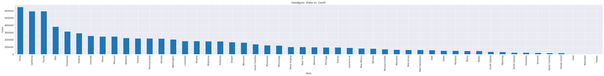

```python
# Use this, and more code cells, to explore your data. Don't forget to add
#   Markdown cells to document your observations and findings.
handgun_state = gun_data.groupby(['state']).sum()['handgun'].sort_values(ascending=False)
longgun_state = gun_data.groupby(['state']).sum()['long_gun'].sort_values(ascending=False)
othergun_state = gun_data.groupby(['state']).sum()['other'].sort_values(ascending=False)
multigun_state = gun_data.groupby(['state']).sum()['multiple'].sort_values(ascending=False)

plt.figure(1, figsize = (50,20))
plt.subplot(411)
ax = handgun_state.plot(kind='bar')
plt.title('Handguns: State vs. Count')
plt.xlabel('State')
plt.ylabel('Count');
```

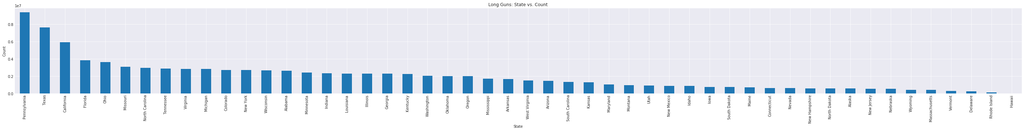

```python
plt.figure(1, figsize = (50,20))
plt.subplot(412)
bx = longgun_state.plot(kind='bar')
plt.title('Long Guns: State vs. Count')
plt.xlabel('State')
plt.ylabel('Count');
```

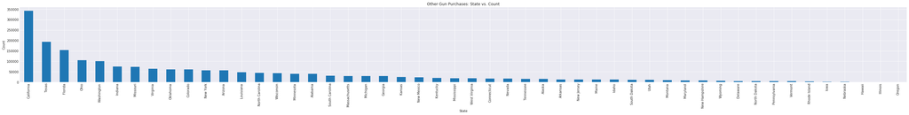

```python
plt.figure(1, figsize = (50,20))
plt.subplot(412)
cx = othergun_state.plot(kind='bar')
plt.title('Other Gun Purchases: State vs. Count')
plt.xlabel('State')
plt.ylabel('Count');
```

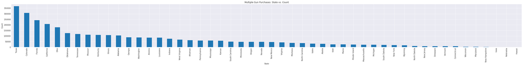

```python
plt.figure(1, figsize = (50,20))
plt.subplot(412)
dx = multigun_state.plot(kind='bar')
plt.title('Multiple Gun Purchases: State vs. Count')
plt.xlabel('State')
plt.ylabel('Count');
```

### Has gun registration gone up or down with time? Are there milestones (spikes or dips in the time-series data)?

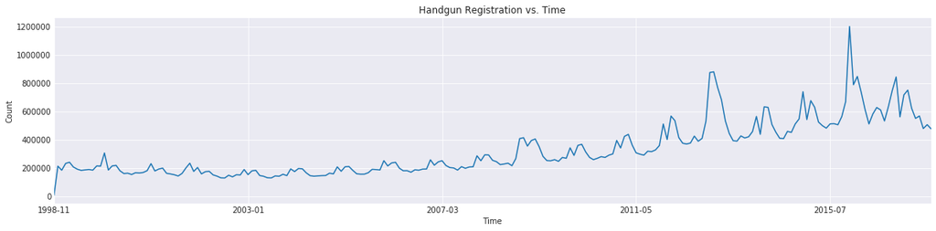

```python
# Continue to explore the data to address your additional research
#   questions. Add more headers as needed if you have more questions to
#   investigate.
handgun_counts = gun_data.groupby(['month']).sum()['handgun']
longgun_counts = gun_data.groupby(['month']).sum()['long_gun']
othergun_counts = gun_data.groupby(['month']).sum()['other']
multigun_counts = gun_data.groupby(['month']).sum()['multiple']


plt.figure(1, figsize = (20,20))

plt.subplot(411)
handgunplt = handgun_counts.plot(kind='line')
plt.title('Handgun Registration vs. Time')
plt.xlabel('Time')
plt.ylabel('Count');
```

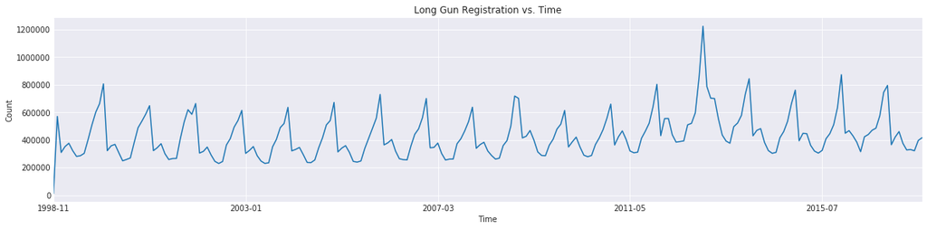

```python
plt.figure(1, figsize = (20,20))

plt.subplot(412)
longgunplt = longgun_counts.plot(kind='line')
plt.title('Long Gun Registration vs. Time')
plt.xlabel('Time')
plt.ylabel('Count');
```

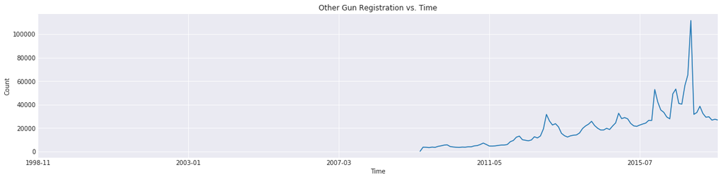

```python
plt.figure(1, figsize = (20,20))

plt.subplot(413)
othergunplt = othergun_counts.plot(kind='line')
plt.title('Other Gun Registration vs. Time')
plt.xlabel('Time')
plt.ylabel('Count');
```

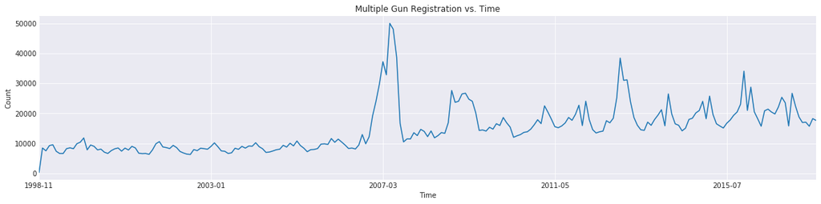

```python
plt.figure(1, figsize = (20,20))

plt.subplot(414)
multigunplt = multigun_counts.plot(kind='line')
plt.title('Multiple Gun Registration vs. Time')
plt.xlabel('Time')
plt.ylabel('Count');
```

Some interesting trends can be seen in the above graphs. Firstly, Handguns spike periodically but still show an upward trajectory in baseline, meaning there is a clear rise in handgun registration. Long Gun registration is similarly period, but does not have the upward baseline trend, indicating that long gun registration is somewhat stable. The other gun category only seems to have bee a relativley recent addition to the NICS background check, appearing for the first time in around 2009. This trend seems to be rising, but has the least values associated with it so can not be held to the same rigor as the insight provided from the other trends. Lastly, the multiple gun registration trends shows a relatively stable trend up until around 2007/2008 when it spikes to a high of 50,000 and has periodic but nonetheless arresting levels of registration. Prior to 2007, there appears to be no instance of multiple gun registrations upwards of 20,000 but post-2007 multiple gun registrations of 20,000 occur seemingly at least once a year.

### Is gun registration effected by levels of income/poverty levels?

```python
#make dataframe of relevant details
censincome = censdata.transpose()
medInc = censincome[47]
PerCapInc = censincome[48]
PovRates = censincome[49]

#.replace('[\%,]', '', regex=True).astype(float).
#Make readable
medInc = medInc.drop('Fact', axis=0).replace('[\$,]', '', regex=True).astype(float)
PerCapInc = PerCapInc.drop('Fact', axis=0).replace('[\$,]', '', regex=True).astype(float).sort_values(ascending=False)
PovRates = PovRates.drop('Fact', axis=0).replace('[\%,]', '', regex=True).astype(float).sort_values(ascending=False)
```

[output not shown]

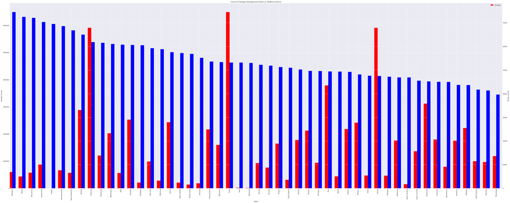

```python
fig = plt.figure(figsize = (50,20)) # Create matplotlib figure

ax = fig.add_subplot(111) # Create matplotlib axes
ax2 = ax.twinx() # Create another axes that shares the same x-axis as ax.
bar_width = 0.35

opacity = 0.4
error_config = {'ecolor': '0.3'}
handgun_alpha = gun_data.groupby(['state']).sum()['handgun']

combined = pd.concat([handgun_alpha, medInc], axis=1)
combined = combined.sort_values(47, ascending=False)

combined['handgun'].plot(kind='bar', color='red', ax=ax, width=bar_width, position=1)
combined[47].plot(kind='bar', color='blue', ax=ax2, width=bar_width, position=0)

ax.set_xlabel('States')
ax.set_ylabel('Handgun Counts')
ax2.set_ylabel('Median Income')
ax.set_title('Count of Handgun Background Checks vs. Median Incomce')
ax.legend()

fig.tight_layout()
plt.show()
```

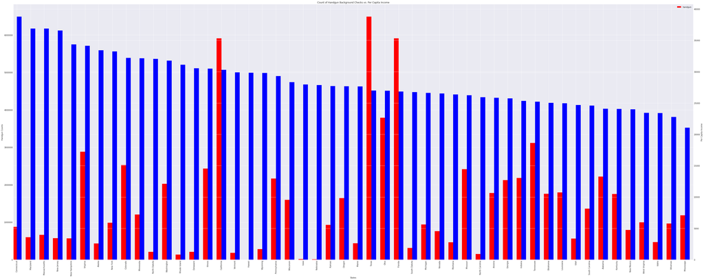

```python
fig = plt.figure(figsize = (50,20)) # Create matplotlib figure

ax = fig.add_subplot(111) # Create matplotlib axes
ax2 = ax.twinx() # Create another axes that shares the same x-axis as ax.
bar_width = 0.35

opacity = 0.4
error_config = {'ecolor': '0.3'}
handgun_alpha = gun_data.groupby(['state']).sum()['handgun']

combined = pd.concat([handgun_alpha, PerCapInc], axis=1)
combined = combined.sort_values(48, ascending=False)

combined['handgun'].plot(kind='bar', color='red', ax=ax, width=bar_width, position=1)
combined[48].plot(kind='bar', color='blue', ax=ax2, width=bar_width, position=0)

ax.set_xlabel('States')
ax.set_ylabel('Handgun Counts')
ax2.set_ylabel('Per Capita Income')
ax.set_title('Count of Handgun Background Checks vs. Per Capita Income')
ax.legend()

fig.tight_layout()
plt.show()
```

[figure not shown]

```python
fig = plt.figure(figsize = (50,20)) # Create matplotlib figure

ax = fig.add_subplot(111) # Create matplotlib axes
ax2 = ax.twinx() # Create another axes that shares the same x-axis as ax.
bar_width = 0.35

opacity = 0.4
error_config = {'ecolor': '0.3'}
handgun_alpha = gun_data.groupby(['state']).sum()['handgun']

combined = pd.concat([handgun_alpha, PovRate], axis=1)
combined = combined.sort_values(49, ascending=False)

combined['handgun'].plot(kind='bar', color='red', ax=ax, width=bar_width, position=1)
combined[49].plot(kind='bar', color='blue', ax=ax2, width=bar_width, position=0)

ax.set_xlabel('States')
ax.set_ylabel('Handgun Counts')
ax2.set_ylabel('Poverty Rate')
ax.set_title('Count of Handgun Background Checks vs. Poverty Rate')
ax.legend()

fig.tight_layout()
plt.show()
```

## Conclusions

As mentioned through out the project, none of these findings are scientific or rigorous. These findings have not been proven through rigorous hypothesis or regression testing and should not be taken as valid. One of the most frustrating aspects to this analysis was the amount of missing data. The most clear example is the Other Gun vs. Time graph, which shows how the the other gun data was seemingly only trended 12 or so years after the NICS was established. I am not alone in my frustration witht he incomplete data as there is even a movement to identify and correct the NICS dataset called FixtheNICS. A corollary that comes with the 'Other Gun vs. Time' graph is how there is no mention of how data collection methodologies changed through the years. In the analysis, I looked to the 'Multiple Gun vs. Time' and saw a clear difference in trending before and after 2007. Could this be due to a more accurate data colleciton method? Unfortunately, unlike the census data, the NICS dataset is not as well annotated.

That said, certain exploratory hypotheses can be formulated at this stage, such as "Handgun registration is rising over time" or "Multiple gun registrations increased after 2007."

> **Tip**: Once you are satisfied with your work, you should save a copy of the report in HTML or PDF form. Before exporting your report, check over it to make sure that the flow of the report is complete. You should probably remove all of the "Tip" quotes like this one so that the presentation is as tidy as possible. It's also a good idea to look over the project rubric, found on the project submission page at the end of the lesson.

> To export the report to the workspace, you should run the code cell below. If it worked correctly, you should get a return code of 0, and you should see the generated .html file in the workspace directory (click on the jupyter icon in the upper left). Alternatively, you can download the html report via the **File** > **Download as** submenu and then manually upload it to the workspace directory. Once you've done this, you can submit your project by clicking on the "Submit Project" button in the lower right. Congratulations!

```python
from subprocess import call
call(['python', '-m', 'nbconvert', 'Investigate_a_Dataset.ipynb'])
```

```
0
```